# Bank Marketing (Original Data)

# Introduction

## Project Objective

This project aims to build a workable model to predict if a client will subscribe a term deposit. Key features of clients who did subscribe a term deposit will be discovered and used for marketing. For example, what are the potential client group in terms of age, job, previous relationship with the bank, etc.

## About the attributes

Input variables: # bank client data: 1 - age (numeric) 2 - job : type of job (categorical: “admin.”,“unknown”,“unemployed”,“management”,“housemaid”,“entrepreneur”,“student”, “blue-collar”,“self-employed”,“retired”,“technician”,“services”) 3 - marital : marital status (categorical: “married”,“divorced”,“single”; note: “divorced” means divorced or widowed) 4 - education (categorical: “unknown”,“secondary”,“primary”,“tertiary”) 5 - default: has credit in default? (binary: “yes”,“no”) 6 - balance: average yearly balance, in euros (numeric) 7 - housing: has housing loan? (binary: “yes”,“no”) 8 - loan: has personal loan? (binary: “yes”,“no”) # related with the last contact of the current campaign: 9 - contact: contact communication type (categorical: “unknown”,“telephone”,“cellular”) 10 - day: last contact day of the month (numeric) 11 - month: last contact month of year (categorical: “jan”, “feb”, “mar”, …, “nov”, “dec”) 12 - duration: last contact duration, in seconds (numeric) # other attributes: 13 - campaign: number of contacts performed during this campaign and for this client (numeric, includes last contact) 14 - pdays: number of days that passed by after the client was last contacted from a previous campaign (numeric, -1 means client was not previously contacted) 15 - previous: number of contacts performed before this campaign and for this client (numeric) 16 - poutcome: outcome of the previous marketing campaign (categorical: “unknown”,“other”,“failure”,“success”)

Output variable (desired target): 17 - y - has the client subscribed a term deposit? (binary: “yes”,“no”)

For source and attribute info of the data set, please refer to https://archive.ics.uci.edu/ml/datasets/bank+marketing

# Understand the data

Import the data set

```r
library(tidyverse)
bank <- read_csv2("/home/junyan26/DATA/Bank_Marketing/bank/bank-full.csv", col_types = cols())
```

```
Using ',' as decimal and '.' as grouping mark. Use read_delim() for more control.
```

```r
nrow(bank)
```

```
[1] 45211
```

```r
ncol(bank)
```

```
[1] 17
```

```r
print(head(bank))
```

| age | job | marital | education | default | balance | housing | loan | contact | day | month | duration | campaign | pdays | previous | poutcome | y |
| --- | --- | --- | --- | --- | --- | --- | --- | --- | --- | --- | --- | --- | --- | --- | --- | --- |
| 58 | management | married | tertiary | no | 2143 | yes | no | unknown | 5 | may | 261 | 1 | -1 | 0 | unknown | no |
| 44 | technician | single | secondary | no | 29 | yes | no | unknown | 5 | may | 151 | 1 | -1 | 0 | unknown | no |
| 33 | entrepreneur | married | secondary | no | 2 | yes | yes | unknown | 5 | may | 76 | 1 | -1 | 0 | unknown | no |
| 47 | blue-collar | married | unknown | no | 1506 | yes | no | unknown | 5 | may | 92 | 1 | -1 | 0 | unknown | no |
| 33 | unknown | single | unknown | no | 1 | no | no | unknown | 5 | may | 198 | 1 | -1 | 0 | unknown | no |
| 35 | management | married | tertiary | no | 231 | yes | no | unknown | 5 | may | 139 | 1 | -1 | 0 | unknown | no |

```r
summary(bank)
```

```
      age            job              marital           education           default             balance
 Min.   :18.00   Length:45211       Length:45211       Length:45211       Length:45211       Min.   : -8019
 1st Qu.:33.00   Class :character   Class :character   Class :character   Class :character   1st Qu.:    72
 Median :39.00   Mode  :character   Mode  :character   Mode  :character   Mode  :character   Median :   448
 Mean   :40.94                                                                               Mean   :  1362
 3rd Qu.:48.00                                                                               3rd Qu.:  1428
 Max.   :95.00                                                                               Max.   :102127
   housing              loan             contact               day           month              duration
 Length:45211       Length:45211       Length:45211       Min.   : 1.00   Length:45211       Min.   :   0.0
 Class :character   Class :character   Class :character   1st Qu.: 8.00   Class :character   1st Qu.: 103.0
 Mode  :character   Mode  :character   Mode  :character   Median :16.00   Mode  :character   Median : 180.0
                                                          Mean   :15.81                      Mean   : 258.2
                                                          3rd Qu.:21.00                      3rd Qu.: 319.0
                                                          Max.   :31.00                      Max.   :4918.0
    campaign          pdays          previous          poutcome              y
 Min.   : 1.000   Min.   : -1.0   Min.   :  0.0000   Length:45211       Length:45211
 1st Qu.: 1.000   1st Qu.: -1.0   1st Qu.:  0.0000   Class :character   Class :character
 Median : 2.000   Median : -1.0   Median :  0.0000   Mode  :character   Mode  :character
 Mean   : 2.764   Mean   : 40.2   Mean   :  0.5803
 3rd Qu.: 3.000   3rd Qu.: -1.0   3rd Qu.:  0.0000
 Max.   :63.000   Max.   :871.0   Max.   :275.0000
```

```r
is_yes <- bank[bank$y == "yes", 17]
n_yes <- nrow(is_yes)
#n_yes
is_no <- bank[bank$y == "no", 17]
n_no <- nrow(is_no)
#n_no
n_yes_no <- data.frame(c(n_yes, n_no))
n_yes_no$class <- c("yes", "no")
colnames(n_yes_no) <- c("count", "class")
n_yes_no <- n_yes_no[, c(2, 1)]
n_yes_no
```

| class | count |
| --- | --- |
| yes | 5289 |
| no | 39922 |

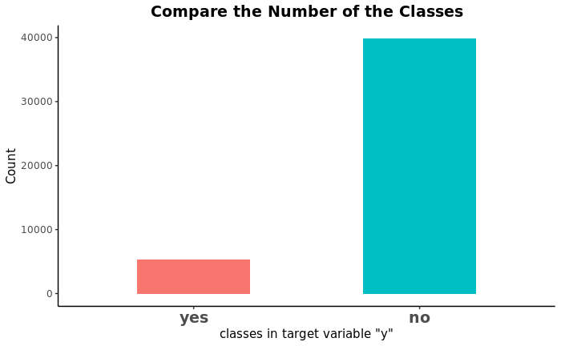

```r
library(ggplot2)
ggplot(data=n_yes_no, aes(x=reorder(class, count), y=count, fill=reorder(class, count))) +
  geom_bar(stat="identity", width=0.5)+
  theme_classic() + ylab("Count") + xlab("classes in target variable \"y\"") +
  ggtitle("Compare the Number of the Classes") +
  theme(plot.title = element_text(hjust = 0.5, size=14, face="bold"),
        axis.text.x = element_text(hjust = 0.5, face="bold", size=14))+
  guides(fill=FALSE, color=FALSE)
```

```r
sapply(bank, function(x) sum(is.na(x)))
```

```
      age       job   marital education   default   balance   housing      loan   contact       day     month
        0         0         0         0         0         0         0         0         0         0         0
 duration  campaign     pdays  previous  poutcome         y
        0         0         0         0         0         0
```

There is no missing data in the data set.

**Turn categorical variables into numerical.**

```r
sapply(bank, class)
```

```
        age         job     marital   education     default     balance     housing        loan     contact
  "numeric" "character" "character" "character" "character"   "numeric" "character" "character" "character"
        day       month    duration    campaign       pdays    previous    poutcome           y
  "numeric" "character"   "numeric"   "numeric"   "numeric"   "numeric" "character" "character"
```

```r
c <- colnames(dplyr::select_if(bank, is.character))
bank[c] <- lapply(bank[c], factor)
sapply(bank, class)
```

```
      age       job   marital education   default   balance   housing      loan   contact       day     month
"numeric"  "factor"  "factor"  "factor"  "factor" "numeric"  "factor"  "factor"  "factor" "numeric"  "factor"
 duration  campaign     pdays  previous  poutcome         y
"numeric" "numeric" "numeric" "numeric"  "factor"  "factor"
```

```r
bank_numeric <- bank
bank_numeric[c] <- lapply(bank_numeric[c], factor)
sapply(bank_numeric, class)
```

```
      age       job   marital education   default   balance   housing      loan   contact       day     month
"numeric"  "factor"  "factor"  "factor"  "factor" "numeric"  "factor"  "factor"  "factor" "numeric"  "factor"
 duration  campaign     pdays  previous  poutcome         y
"numeric" "numeric" "numeric" "numeric"  "factor"  "factor"
```

```r
must_convert <- sapply(bank_numeric,is.factor)
#must_convert
bank_numeric_temp <- sapply(bank_numeric[,must_convert],unclass)
bank_numeric <- cbind(bank_numeric[,!must_convert],bank_numeric_temp)
```

Reorder the column names

```r
cnames = colnames(bank)
bank_numeric <- bank_numeric[, cnames]
```

“bank_numeric” is a dataset generated from “bank” and with all numerical data.

**Examine the correlation coefficient between variables.**

```r
cormat <- round(cor(bank_numeric),2)
```

```r
library(reshape2)
melted_cormat <- melt(cormat)
```

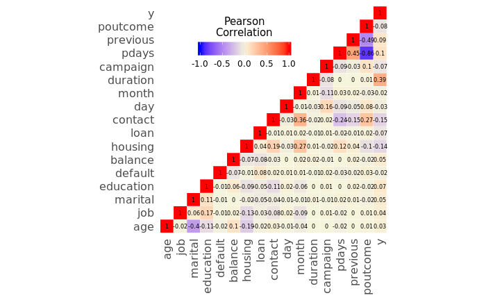

```r
# Get lower triangle of the correlation matrix
  get_lower_tri <- function(cormat){
    cormat[upper.tri(cormat)] <- NA
    return(cormat)
  }
  # Get upper triangle of the correlation matrix
  get_upper_tri <- function(cormat){
    cormat[lower.tri(cormat)] <- NA
    return(cormat)
  }

upper_tri <- get_upper_tri(cormat)
# Melt the correlation matrix
library(reshape2)
melted_cormat <- melt(upper_tri, na.rm = TRUE)
# Heatmap
library(ggplot2)
ggplot(data = melted_cormat, aes(Var2, Var1, fill = value))+
 geom_tile(color = "white")+
 scale_fill_gradient2(low = "blue", high = "red", mid = "beige",
   midpoint = 0, limit = c(-1,1), space = "Lab",
   name="Pearson\nCorrelation") +
  theme_minimal()+
 theme(axis.text.x = element_text(angle = 90, vjust = 0.5,
    size = 12, hjust = 1), axis.text.y = element_text(vjust = 0.5,
    size = 12, hjust = 1))+
 coord_fixed() +
geom_text(aes(Var2, Var1, label = value), color = "black", size = 2) +
theme(
  axis.title.x = element_blank(),
  axis.title.y = element_blank(),
  panel.grid.major = element_blank(),
  panel.border = element_blank(),
  panel.background = element_blank(),
  axis.ticks = element_blank(),
  legend.justification = c(1, 0),
  legend.position = c(0.6, 0.7),
  legend.direction = "horizontal")+
  guides(fill = guide_colorbar(barwidth = 7, barheight = 1,
                title.position = "top", title.hjust = 0.5))
```

The correlation between variables are not very strong overall. Still, we have some higher correlated variable pair: pday and poutcome.

The correlation for each variable and the output variable “y” is not strong, which makes the project a little difficult.

**Scatterplot Matrix**

The points in a scatterplot matrix can be colored by the class label in classification problems. This can help to spot clear (or unclear) separation of classes and perhaps give an idea of how difficult the problem may.

```r
#pairs(y~., data=bank_numeric, col=bank_numeric$y)
```

# Baseline Model with decision tree and random forest

The classification algorithms require the class label to be categorical.

The order of level is by alphabet. “No” is the positive class by default. Change the order of the levels, so “yes” will be the positive class in the model.

```r
bank$y = factor(bank$y,levels(bank$y)[c(2,1)])
```

```r
levels(bank$y)
```

```
[1] "yes" "no"
```

**Split traning set and test set (original data)**

```r
## 75% of the sample size
size1 <- floor(0.75 * nrow(bank))
## set the seed to make your partition reproducible
set.seed(123)
train_ind1 <- sample(seq_len(nrow(bank)), size = size1)
bank_train1 <- bank[train_ind1, ]
bank_test1 <- bank[-train_ind1, ]
```

**Build baseline model with decision tree.**

```r
library(rpart)
base_dt <- rpart(y ~ .,data = bank_train1, method = "class")
base_dt
```

```
n= 33908

node), split, n, loss, yval, (yprob)
      * denotes terminal node

 1) root 33908 3989 no (0.11764185 0.88235815)
   2) duration>=521.5 3746 1648 no (0.43993593 0.56006407)
     4) duration>=827.5 1342  564 yes (0.57973174 0.42026826) *
     5) duration< 827.5 2404  870 no (0.36189684 0.63810316)
      10) poutcome=success 111   21 yes (0.81081081 0.18918919) *
      11) poutcome=failure,other,unknown 2293  780 no (0.34016572 0.65983428) *
   3) duration< 521.5 30162 2341 no (0.07761422 0.92238578)
     6) poutcome=success 978  354 yes (0.63803681 0.36196319)
      12) duration>=161.5 697  166 yes (0.76183644 0.23816356) *
      13) duration< 161.5 281   93 no (0.33096085 0.66903915) *
     7) poutcome=failure,other,unknown 29184 1717 no (0.05883361 0.94116639) *
```

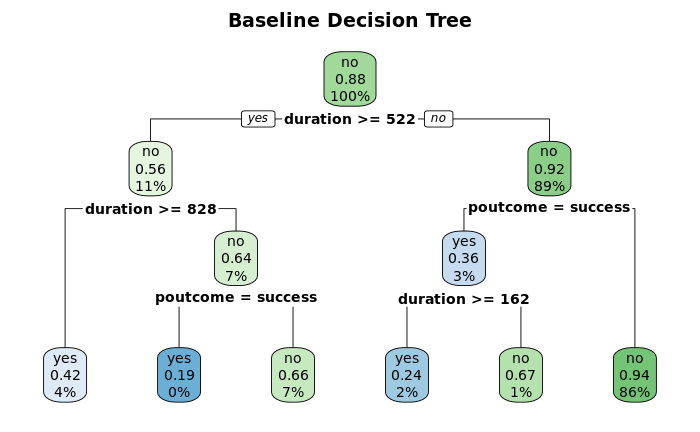

```r
library(rpart.plot)
rpart.plot(base_dt, main="Baseline Decision Tree")
```

The baselime decision tree selects duration, poutcome as predictors.

Make prediction on test data

```r
bank_test1$Prediction_DT <- predict(base_dt, bank_test1[, 1:16], type="class")
#shows the true class and prediction class
head(bank_test1[, 17:18])
```

| y | Prediction_DT |
| --- | --- |
| no | no |
| no | no |
| no | no |
| no | yes |
| no | no |
| no | yes |

Evaluate the base dicision tree with confusion matrix.

```r
library(caret)
confusionMatrix(bank_test1$Prediction_DT, bank_test1$y, positive="yes")
```

```
Confusion Matrix and Statistics

          Reference
Prediction  yes   no
       yes  447  268
       no   853 9735

               Accuracy : 0.9008
                 95% CI : (0.8952, 0.9063)
    No Information Rate : 0.885
    P-Value [Acc > NIR] : 0.00000003931

                  Kappa : 0.3942
 Mcnemar's Test P-Value : < 0.00000000000000022

            Sensitivity : 0.34385
            Specificity : 0.97321
         Pos Pred Value : 0.62517
         Neg Pred Value : 0.91944
             Prevalence : 0.11501
         Detection Rate : 0.03955
   Detection Prevalence : 0.06326
      Balanced Accuracy : 0.65853

       'Positive' Class : yes
```

**Build baseline model with random forest.**

```r
library(randomForest)
base_rf <- randomForest(y ~ . , data=bank_train1, ntree=100, mtry=2, importance=TRUE)
```

Get one of the tree from the random forest model.

```r
gTree <- getTree(base_rf, 1, labelVar=TRUE)
gTree
```

|  | left daughter | right daughter | split var | split point | status | prediction |
| --- | --- | --- | --- | --- | --- | --- |
| 1 | 2 | 3 | duration | 452.5 | 1 | NA |
| 2 | 4 | 5 | day | 3.5 | 1 | NA |
| 3 | 6 | 7 | housing | 1.0 | 1 | NA |
| 4 | 8 | 9 | housing | 1.0 | 1 | NA |
| 5 | 10 | 11 | duration | 205.5 | 1 | NA |
| 6 | 12 | 13 | contact | 3.0 | 1 | NA |
| 7 | 14 | 15 | loan | 1.0 | 1 | NA |
| 8 | 16 | 17 | loan | 1.0 | 1 | NA |
| 9 | 18 | 19 | marital | 2.0 | 1 | NA |
| 10 | 20 | 21 | previous | 0.5 | 1 | NA |

[output cut: 990 more lines]

To visualize random forest, run:

options(repos=‘http://cran.rstudio.org’) have.packages <- installed.packages() cran.packages <- c(‘devtools’,‘plotrix’,‘randomForest’,‘tree’) to.install <- setdiff(cran.packages, have.packages[,1]) if(length(to.install)>0) install.packages(to.install)

library(devtools) if(!(‘reprtree’ %in% installed.packages())){ install_github(‘araastat/reprtree’) } for(p in c(cran.packages, ‘reprtree’)) eval(substitute(library(pkg), list(pkg=p)))

(https://stats.stackexchange.com/questions/41443/how-to-actually-plot-a-sample-tree-from-randomforestgettree)

[figure not shown]

```r
library(reprtree)
reprtree:::plot.getTree(base_rf, 1)
```

*** Visualization needs improvement.

Make prediction on test data

```r
bank_test1$Prediction_RF<- predict(base_rf, bank_test1[, 1:16], type="class")
```

```r
head(bank_test1[, c(17, 19)])
```

| y | Prediction_RF |
| --- | --- |
| no | no |
| no | no |
| no | no |
| no | no |
| no | no |
| no | no |

Confusion Mat4rix for the base random forest model.

```r
library(caret)
confusionMatrix(bank_test1$Prediction_RF, bank_test1$y)
```

```
Confusion Matrix and Statistics

          Reference
Prediction  yes   no
       yes  358  174
       no   942 9829

               Accuracy : 0.9013
                 95% CI : (0.8956, 0.9067)
    No Information Rate : 0.885
    P-Value [Acc > NIR] : 0.00000001655

                  Kappa : 0.3472
 Mcnemar's Test P-Value : < 0.00000000000000022

            Sensitivity : 0.27538
            Specificity : 0.98261
         Pos Pred Value : 0.67293
         Neg Pred Value : 0.91254
             Prevalence : 0.11501
         Detection Rate : 0.03167
   Detection Prevalence : 0.04707
      Balanced Accuracy : 0.62899

       'Positive' Class : yes
```

```r
base_rf$confusion
```

```
     yes    no class.error
yes 1177  2812  0.70493858
no   507 29412  0.01694575
```

```r
base_rf$importance
```

```
                   yes             no MeanDecreaseAccuracy MeanDecreaseGini
age       0.0090624375  0.00342064393        0.00408334472       384.072825
job       0.0092472719  0.00025835046        0.00131795527       297.887820
marital   0.0046676579 -0.00000721125        0.00054505273        92.728008
education 0.0044333864  0.00063375087        0.00107545104       112.567404
default   0.0002243962  0.00002186090        0.00004562667         8.006571
balance   0.0041371173  0.00010237913        0.00057855004       370.379911
housing   0.0150259269  0.00325377260        0.00463946586       111.894965
loan      0.0046689461 -0.00023605291        0.00034015204        39.421906
contact   0.0181491970  0.01501026347        0.01538324196       113.523638
day       0.0022197590  0.00831519941        0.00759914599       313.807305
month     0.0270758624  0.03314315151        0.03243038944       632.579335
duration  0.1426641379  0.01459714916        0.02965272323      1392.147431
campaign  0.0048264542  0.00075556858        0.00123281697       155.906353
pdays     0.0193742593  0.01482516345        0.01536098753       245.730851
previous  0.0185578407  0.01076806237        0.01168727442       152.845717
poutcome  0.0245269297  0.01585729191        0.01687111868       431.728640
```

**Find out the importance of the variables.**

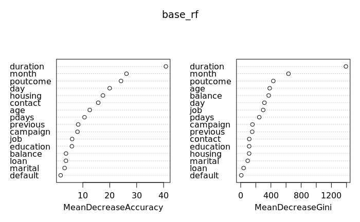

```r
library(randomForest)
varImpPlot(base_rf)
```

```r
cm <- cor(bank_numeric[, 1:16])
highly_cor <- findCorrelation(cm, cutoff = 0.5, verbose = TRUE)
```

```
Compare row 16  and column  14 with corr  0.858
  Means:  0.138 vs 0.06 so flagging column 16
All correlations <= 0.5
```

```r
highly_cor
```

```
[1] 16
```

# PCA and Classification

This section runs the Principle Component Analysis and build classification model on the result.

## PCA

PCA requires numerical data. “bank_nc” has numerical predictors and categorical class label.

```r
bank$y <- as.factor(bank$y)
class_label <- bank[,17]
bank_nc <- cbind(bank_numeric[c(1:16)], class_label)
```

**Split traning set and test set**

```r
## 75% of the sample size
pca_size <- floor(0.75 * nrow(bank_nc))
## set the seed to make your partition reproducible
set.seed(123)
pca_train_ind <- sample(seq_len(nrow(bank_nc)), size = pca_size)
pca_train <- bank_nc[pca_train_ind, ]
pca_test <- bank_nc[-pca_train_ind, ]
```

```r
prin_comp <- princomp(pca_train[c(1:16)])
names(prin_comp)
```

```
[1] "sdev"     "loadings" "center"   "scale"    "n.obs"    "scores"   "call"
```

```r
prin_comp$center
```

```
         age          job      marital    education      default      balance      housing         loan
  40.8775805    5.3344933    2.1669223    2.2266722    1.0177539 1364.9733101    1.5559455    1.1592250
     contact          day        month     duration     campaign        pdays     previous     poutcome
   1.6408812   15.7965377    6.5202607  258.1902501    2.7575793   40.1620267    0.5818096    3.5625516
```

```r
prin_comp$loadings
```

```
Loadings:
          Comp.1 Comp.2 Comp.3 Comp.4 Comp.5 Comp.6 Comp.7 Comp.8 Comp.9 Comp.10 Comp.11 Comp.12 Comp.13
age                             0.999
job                                           0.846  0.456  0.273
marital                                                                           0.105   0.971
education                                                                 0.371   0.917  -0.128
default
balance    1.000
housing                                                                  -0.119          -0.190  -0.191
loan
contact                                                                  -0.903   0.378
day                                   -0.998
month                                        -0.477  0.443  0.748         0.120
duration          1.000
campaign                                      0.222 -0.770  0.595
pdays                   -1.000
previous                                                          -0.998
poutcome                                                                 -0.117                   0.974
          Comp.14 Comp.15 Comp.16
age
job
marital   -0.199
education
default                   -1.000
balance
housing   -0.952
loan               0.996
contact    0.123
day
month
duration
campaign
pdays
previous
poutcome  -0.182

               Comp.1 Comp.2 Comp.3 Comp.4 Comp.5 Comp.6 Comp.7 Comp.8 Comp.9 Comp.10 Comp.11 Comp.12 Comp.13
SS loadings     1.000  1.000  1.000  1.000  1.000  1.000  1.000  1.000  1.000   1.000   1.000   1.000   1.000
Proportion Var  0.063  0.063  0.062  0.063  0.062  0.063  0.063  0.063  0.063   0.062   0.063   0.063   0.063
Cumulative Var  0.063  0.125  0.188  0.250  0.313  0.375  0.438  0.500  0.563   0.625   0.688   0.750   0.813
               Comp.14 Comp.15 Comp.16
SS loadings      1.000   1.000   1.000
Proportion Var   0.063   0.062   0.063
Cumulative Var   0.875   0.938   1.000
```

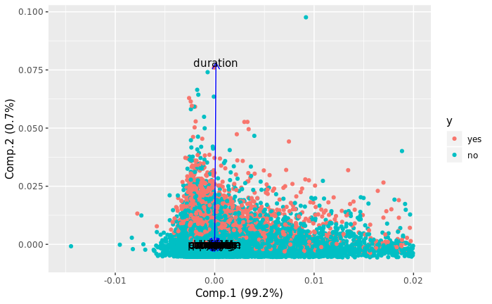

```r
library(ggfortify)
autoplot(prin_comp, data = pca_train, colour = 'y',
         loadings = TRUE, loadings.colour = 'blue', ncol=2,
         loadings.label = TRUE, loadings.label.size = 4, loadings.label.colour = "black",
         xlim=(c(-0.015, 0.02)))
```

```r
summary(prin_comp)
```

```
Importance of components:
                             Comp.1        Comp.2        Comp.3         Comp.4         Comp.5         Comp.6
Standard deviation     3085.9090140 258.705670171 100.171112146 10.53425687804 8.309697009479 3.365930735506
Proportion of Variance    0.9919605   0.006971722   0.001045233  0.00001155942 0.000007192809 0.000001180154
Cumulative Proportion     0.9919605   0.998932270   0.999977503  0.99998906285 0.999996255658 0.999997435812
                               Comp.7          Comp.8          Comp.9          Comp.10          Comp.11
Standard deviation     3.130026110965 2.8237022000373 2.1844076352362 0.81324262450329 0.71853213955808
Proportion of Variance 0.000001020526 0.0000008305503 0.0000004970448 0.00000006889194 0.00000005377997
Cumulative Proportion  0.999998456338 0.9999992868884 0.9999997839332 0.99999985282512 0.99999990660509
                                Comp.12          Comp.13          Comp.14          Comp.15           Comp.16
Standard deviation     0.55760935915848 0.48469896586094 0.44964928265878 0.36237626091705 0.131263274315456
Proportion of Variance 0.00000003238831 0.00000002447216 0.00000002106085 0.00000001367879 0.000000001794794
Cumulative Proportion  0.99999993899340 0.99999996346556 0.99999998452642 0.99999999820521 1.000000000000000
```

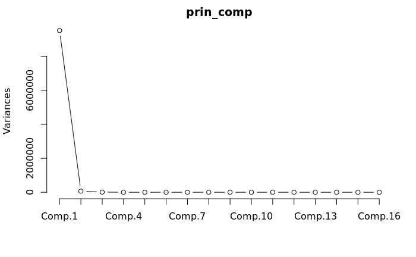

```r
screeplot(prin_comp, type="lines", npc=16)
```

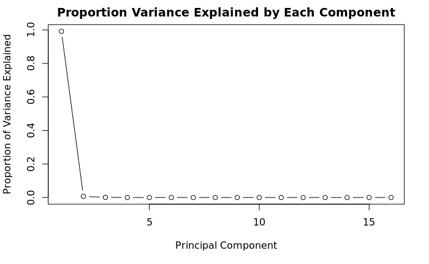

```r
std_dev <- prin_comp$sdev
pr_var <- std_dev^2
prop_varex <- pr_var/sum(pr_var)
plot(prop_varex, xlab = "Principal Component",
             ylab = "Proportion of Variance Explained",
             type = "b", main="Proportion Variance Explained by Each Component")
```

cumulative scree plot

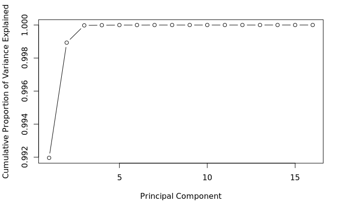

```r
plot(cumsum(prop_varex), xlab = "Principal Component",
              ylab = "Cumulative Proportion of Variance Explained",
              type = "b")
```

```r
pca_train1 <- data.frame(y = pca_train$y, prin_comp$scores)
pca_train1 <- pca_train1[, 1:4]
```

```r
class(pca_train1$y)
```

```
[1] "factor"
```

**Run decision tree on PCA data**

```r
library(rpart)
pca_dt <- rpart(y ~ .,data = pca_train1, method = "class")
pca_dt
```

```
n= 33908

node), split, n, loss, yval, (yprob)
      * denotes terminal node

1) root 33908 3989 no (0.11764185 0.88235815)
  2) Comp.2>=264.2457 3731 1645 no (0.44090056 0.55909944)
    4) Comp.3< 40.20262 1649  723 yes (0.56155246 0.43844754) *
    5) Comp.3>=40.20262 2082  719 no (0.34534102 0.65465898) *
  3) Comp.2< 264.2457 30177 2344 no (0.07767505 0.92232495) *
```

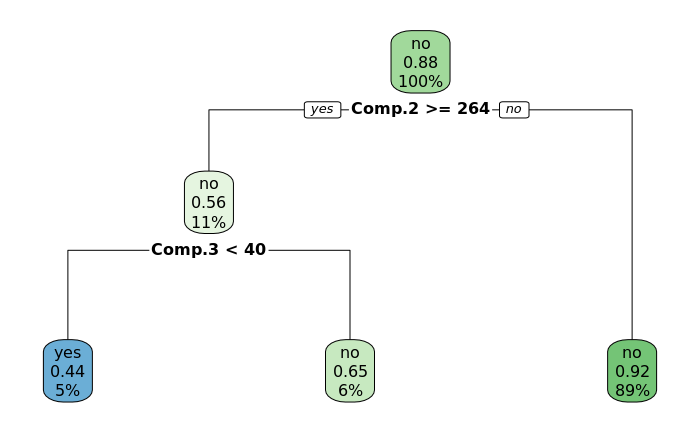

```r
library(rpart.plot)
rpart.plot(pca_dt)
```

Transform test set into PCA

```r
pca_test1 <- predict(prin_comp, newdata = pca_test[c(1:16)])
pca_test1 <- as.data.frame(pca_test1)
pca_test1 <- pca_test1[, 1:3]
```

Make prediction on test data

```r
pca_test1$Prediction_DT <- predict(pca_dt, pca_test1, type="class")
```

```r
pca_test1$y <- pca_test$y
head(pca_test1[,4:5])
```

|  | Prediction_DT | y |
| --- | --- | --- |
| 22 | no | no |
| 26 | no | no |
| 28 | no | no |
| 38 | yes | no |
| 39 | no | no |
| 44 | yes | no |

```r
library(caret)
confusionMatrix(pca_test1$Prediction, pca_test1$y)
```

```
Confusion Matrix and Statistics

          Reference
Prediction  yes   no
       yes  295  232
       no  1005 9771

               Accuracy : 0.8906
                 95% CI : (0.8847, 0.8963)
    No Information Rate : 0.885
    P-Value [Acc > NIR] : 0.03202

                  Kappa : 0.2748
 Mcnemar's Test P-Value : < 0.0000000000000002

            Sensitivity : 0.22692
            Specificity : 0.97681
         Pos Pred Value : 0.55977
         Neg Pred Value : 0.90674
             Prevalence : 0.11501
         Detection Rate : 0.02610
   Detection Prevalence : 0.04662
      Balanced Accuracy : 0.60187

       'Positive' Class : yes
```

**Run random forest on PCA data**

```r
library(randomForest)
pca_rf <- randomForest(y ~ . , data=pca_train1, ntree=100, mtry=2, importance=TRUE)
```

Get one of the tree from the random forest model.

```r
gTree <- getTree(pca_rf, 1, labelVar=TRUE)
gTree
```

|  | left daughter | right daughter | split var | split point | status | prediction |
| --- | --- | --- | --- | --- | --- | --- |
| 1 | 2 | 3 | Comp.3 | 40.8299102 | 1 | NA |
| 2 | 4 | 5 | Comp.2 | 382.7580655 | 1 | NA |
| 3 | 6 | 7 | Comp.2 | 105.9952334 | 1 | NA |
| 4 | 8 | 9 | Comp.3 | -162.0184387 | 1 | NA |
| 5 | 10 | 11 | Comp.2 | 579.9614736 | 1 | NA |
| 6 | 12 | 13 | Comp.2 | -114.5388603 | 1 | NA |
| 7 | 14 | 15 | Comp.1 | 25317.8022647 | 1 | NA |
| 8 | 16 | 17 | Comp.3 | -333.7893295 | 1 | NA |
| 9 | 18 | 19 | Comp.2 | -131.4894824 | 1 | NA |
| 10 | 20 | 21 | Comp.3 | 35.3299268 | 1 | NA |

[output cut: 990 more lines]

Make prediction on test data

```r
pca_test1$Prediction_RF<- predict(pca_rf, pca_test1, type="class")
```

```r
head(pca_test1[,c(4,6)])
```

|  | Prediction_DT | Prediction_RF |
| --- | --- | --- |
| 22 | no | no |
| 26 | no | no |
| 28 | no | no |
| 38 | yes | yes |
| 39 | no | no |
| 44 | yes | yes |

```r
confusionMatrix(pca_test1$Prediction_RF, pca_test1$y)
```

```
Confusion Matrix and Statistics

          Reference
Prediction  yes   no
       yes  403  357
       no   897 9646

               Accuracy : 0.8891
                 95% CI : (0.8831, 0.8948)
    No Information Rate : 0.885
    P-Value [Acc > NIR] : 0.08939

                  Kappa : 0.3348
 Mcnemar's Test P-Value : < 0.0000000000000002

            Sensitivity : 0.31000
            Specificity : 0.96431
         Pos Pred Value : 0.53026
         Neg Pred Value : 0.91492
             Prevalence : 0.11501
         Detection Rate : 0.03565
   Detection Prevalence : 0.06724
      Balanced Accuracy : 0.63716

       'Positive' Class : yes
```